# Shiny Dashboards Made Easy

David Meza

April 5, 2016

## Installation

shinydashboard requires Shiny 0.11 or above. To install, run:

```r
install.packages("shinydashboard")
```

## Basics

A dashboard has three parts: a header, a sidebar, and a body. Here’s the most minimal possible UI for a dashboard page.

```r
## ui.R ##
library(shinydashboard)

dashboardPage(
  dashboardHeader(),
  dashboardSidebar(),
  dashboardBody()
)
```

You can quickly view it at the R console by using the shinyApp() function. (You can also use this code as a single-file app).

```r
## app.R ##
library(shiny)
library(shinydashboard)

ui <- dashboardPage(
  dashboardHeader(),
  dashboardSidebar(),
  dashboardBody()
)

server <- function(input, output) { }

shinyApp(ui, server)
```

Basic Dashboard:

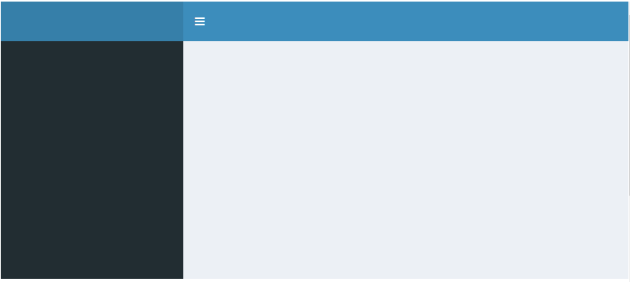

## Add Content

Obviously, this dashboard isn’t very useful. We’ll need to add components that actually do something. In the body we can add boxes that have content.

```r
## app.R ##
library(shinydashboard)

ui <- dashboardPage(
  dashboardHeader(title = "Basic dashboard"),
  dashboardSidebar(),
  dashboardBody(
    # Boxes need to be put in a row (or column)
    fluidRow(
      box(plotOutput("plot1", height = 250)),

      box(
        title = "Controls",
        sliderInput("slider", "Number of observations:", 1, 100, 50)
      )
    )
  )
)

server <- function(input, output) {
  set.seed(122)
  histdata <- rnorm(500)

  output$plot1 <- renderPlot({
    data <- histdata[seq_len(input$slider)]
    hist(data)
  })
}

shinyApp(ui, server)
```

Basic Dashboard Add Content:

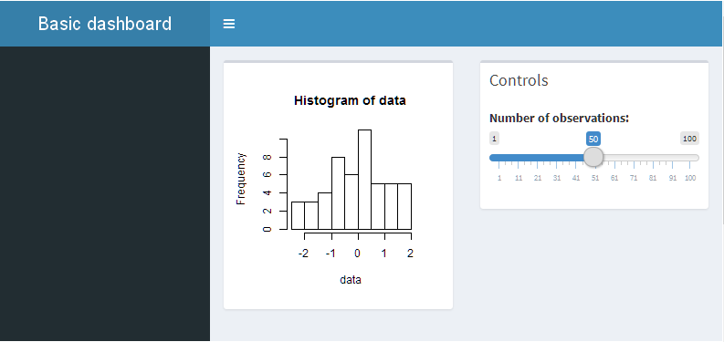

## Add Sidebar

Next, we can add content to the sidebar. For this example we’ll add menu items that behave like tabs. These function similarly to Shiny’s tabPanels: when you click on one menu item, it shows a different set of content in the main body.

There are two parts that need to be done. First, you need to add menuItems to the sidebar, with appropriate tabNames.

In the body, add tabItems with corrsponding values for tabName:

The default display, also shown when the “Dashboard” menu item is clicked:

```r
## app.R ##
library(shinydashboard)

ui <- dashboardPage(
  dashboardHeader(title = "Basic dashboard"),
  dashboardSidebar(
    sidebarMenu(
      menuItem("Dashboard", tabName = "dashboard", icon = icon("dashboard")),
      menuItem("Widgets", tabName = "widgets", icon = icon("th"))
    )
  ),
  dashboardBody(
    tabItems(
      # First tab content
      tabItem(tabName = "dashboard",
        fluidRow(
          box(plotOutput("plot1", height = 250)),

          box(
            title = "Controls",
            sliderInput("slider", "Number of observations:", 1, 100, 50)
          )
        )
      ),

      # Second tab content
      tabItem(tabName = "widgets",
        h2("Widgets tab content")
      )
    )
  )
)

server <- function(input, output) {
  set.seed(122)
  histdata <- rnorm(500)

  output$plot1 <- renderPlot({
    data <- histdata[seq_len(input$slider)]
    hist(data)
  })
}

shinyApp(ui, server)
```

Basic Dashboard Tab 1:

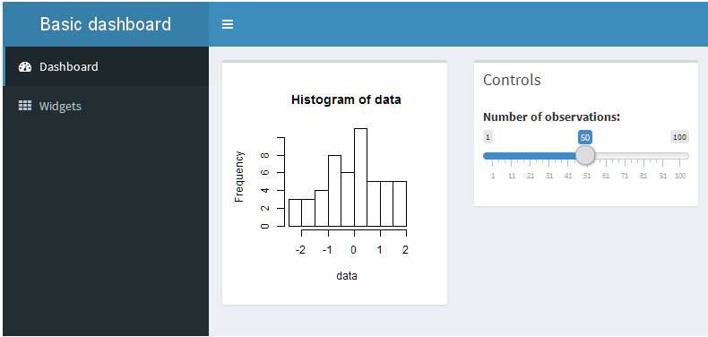

Basic Dashboard Tab 2:

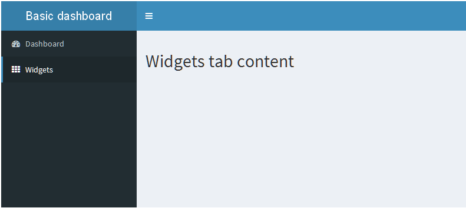

## Expanding Your Basic Dashboard

As your analysis expands and you start to add separate tabs to your dashboard, the amount of code in one `R` file can become unmanageable.

To alleviate this, it will become necessary to split your code into modules for each of your analysis. This allows for greater control and maintenance of your dashboard. Additionally, you will find it easier to debug errors in your code.

To accomplish this, we first need to break up the basic dashboard into Spears files. The map below depicts how we break up the single dashboard file in seven.

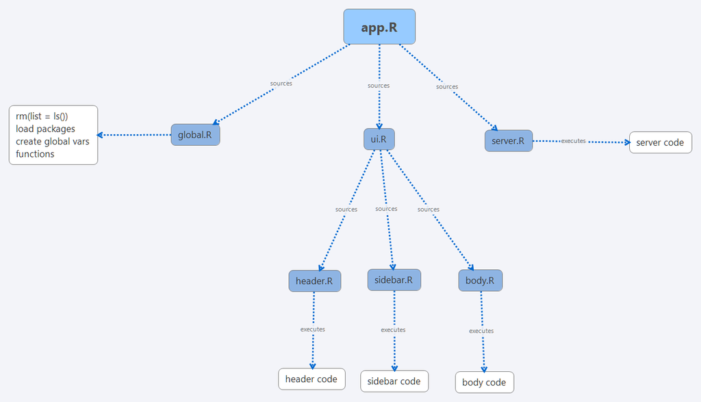

```r
## app.R ##
## This is the starting point for the application
## Run locally if in interactive session (for testing)
if(interactive()) {
     source("global.R")
     source("ui.R")
     source("server.R") ## function(input, out)
     shinyApp(ui, server)
}

## global.R ##
## DO NOT DELETE, NEEDED TO RUN DASHBOARD ##
library(shiny)
library(shinydashboard)
############################################

## Add Your packages here


## Source - Place any functions you want accessible globally in the functions folder


## Global variables - used across pages and apps

## ui.R ##
source("header.R")
source("sidebar.R")
source("body.R")

ui <- dashboardPage(
     header,
     sidebar,
     body
)

## header.R ##
header <- dashboardHeader(title = "Exapnded Basic Dashboard", titleWidth = 500
)

## sidebar.R ##
sidebar <- dashboardSidebar(sidebarMenu(
     menuItem("Dashboard", tabName = "dashboard", icon = icon("dashboard")),
     menuItem("Widgets", tabName = "widgets", icon = icon("th"))
     )
)

## body.R ##
body <- dashboardBody(
     tabItems(
          # First tab content
          tabItem(tabName = "dashboard",
                  fluidRow(
                       box(plotOutput("plot1", height = 250)),

                       box(
                            title = "Controls",
                            sliderInput("slider", "Number of observations:", 1, 100, 50)
                       )
                  )
          ),

          # Second tab content
          tabItem(tabName = "widgets",
                  h2("Widgets tab content")
          )
     )
)

## server.R ##
server <- function(input, output) {
     set.seed(122)
     histdata <- rnorm(500)

     output$plot1 <- renderPlot({
          data <- histdata[seq_len(input$slider)]
          hist(data)
     })
}
```

## Modular Dashboard

Expanding that further, we now break up the **body.R** and **server.R** files. Separate folders or subApps are created for each tab in the dashboard containing their own **ui.r** and **server.R** file. **body.R** sources the **ui.R** and creates an object holding the dashboard body and tabItem created by the **ui.R** it sourced. The main **server.R** file is now a function that sources the **server.R** file in the folder.

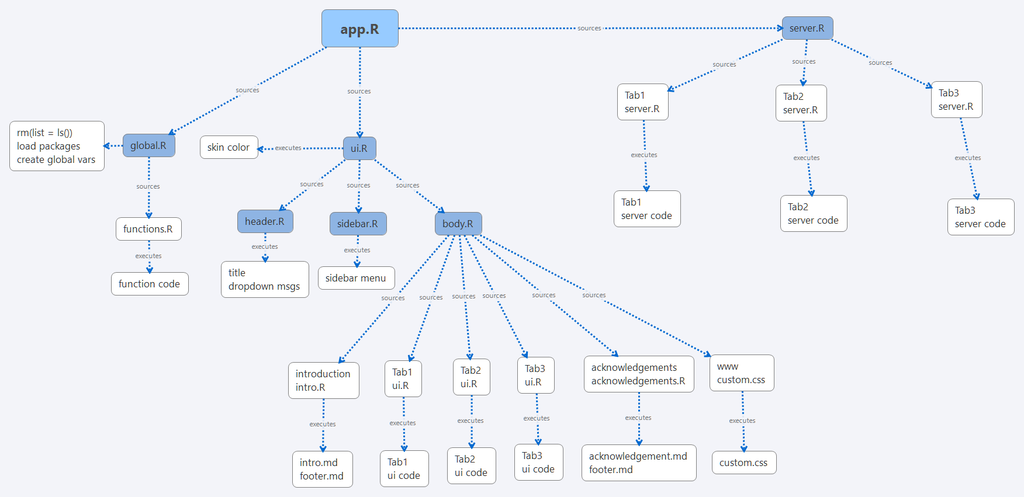

### Main body.r

```r
## Main body.R ##
## Tab Items
## Introduction-----------------------------------------
source('intro/intro.r', local = TRUE)
intro <- tabItem(tabName = "intro", intro.box)

## Dashboard Boxes Example --------------------------------
source('DBboxes/ui.R', local = TRUE)
dbboxes <- tabItem(tabName = "dbboxes", dbboxes.box)

## Dashboard ----------------------------------------------
source('dashboard/ui.R', local = TRUE)
dashboard <- tabItem(tabName = "dashboard", dashboard.box)

## maps ------------------------------------------------
source('maps/ui.R', local = TRUE)
maps <- tabItem(tabName = "maps", maps.box)

## Topic Modeling -------------------------------------
source("LDAvis/ui.R", local = TRUE)
lda <- tabItem(tabName = "lda", lda.box)

## Acknowledgements ------------------------------------
source('acknowledgements/acknowledgements.R', local = TRUE)
ack <- tabItem(tabName = "ack", ack.box)


body <- dashboardBody(
     tabItems(
          intro,
          dbboxes,
          dashboard,
          maps,
          lda,
          ack
     )
)
```

### Main server.R

```r
## Main server.R ##
server <- function(input, output, session) {
     ## Introduction Tab
     source("intro/intro.R", local = TRUE)
     ## Dashboard Boxes
     source("DBboxes/server.R", local = TRUE)
     ## Dashboard Tab
     source("dashboard/server.R", local = TRUE)
     ## Maps Tab
     source("maps/server.R", local = TRUE)
     ## Topic Modeling LDA Tab
     source("LDAvis/server.R", local = TRUE)
     ## Acknowledgements
     source("acknowledgements/acknowledgements.R", local = TRUE)
}
```

### subApp ui.R

```r
## Example subApp ui.R ##
maps.box <- fluidPage(

     leafletOutput("CODmap", width = "100%", height = 600),
     DT::dataTableOutput("building_info")

)
```

### subApp server.R

```r
## Example subApp server.R ##
## COD map server code
JSC <- "Johnson Space Center"
JSCcoords <- geocode("Johnson Space Center")
JSCRealProperty <- readRDS("data/JSCRealProperty.rds")
JSCBuildings <- filter(JSCRealProperty, !is.na(latitude))
## Dummy Data to represent power usage
over <- JSCBuildings[1:66, ]
avearage <- JSCBuildings[67:132, ]
low <- JSCBuildings[133:197, ]
##-------------------------------

JSCmap <- leaflet() %>%
     addTiles() %>%
     setView(JSCcoords[1], JSCcoords[2], zoom = 15) %>%
     addCircleMarkers(data = JSCBuildings, lng = ~ longitude, lat = ~ latitude, radius = (JSCBuildings$BookValue)/1000000, layerId = NULL,
                      group = "JSC Buildings", stroke = TRUE, color = "blue", weight = 5, opacity = 0.5,
                      fill = TRUE, fillColor = "blue", fillOpacity = 0.2, dashArray = NULL,
                      popup = paste(JSCBuildings$PropertyName, JSCBuildings$PriorYrOperating),
                      options = pathOptions(), clusterOptions = NULL, clusterId = NULL)%>%
     addCircleMarkers(data = over, lng = ~ longitude, lat = ~ latitude, group = "High Power", color = "red") %>%
     addCircleMarkers(data = avearage, lng = ~ longitude, lat = ~ latitude, group = "Avg. Power", color = "yellow") %>%
     addCircleMarkers(data = low, lng = ~ longitude, lat = ~ latitude, group = "Low Power", color = "green") %>%
     hideGroup("High Power") %>%
     hideGroup("Avg. Power") %>%
     hideGroup("Low Power") %>%
     addLayersControl(baseGroups = "JSC Buildings", overlayGroups = c("High Power", "Avg. Power", "Low Power"),
                      options = layersControlOptions(collapsed = FALSE))

output$CODmap <- renderLeaflet(JSCmap)
output$building_info <- renderDataTable(over)
```